# RNA-seq in Bioconductor exercises

Tom Carroll

In todays session we will work with some of the RNA-seq data of adult mouse tissues from Bing Ren’s lab, Liver and Heart. - More information on liver data [can be found here](https://www.encodeproject.org/experiments/ENCSR000CHB/) - More information on heart data [can be found here](https://www.encodeproject.org/experiments/ENCSR000CGZ/)

- Precounted RNAseq reads in genes for these tissues can be found as an R data object in **/Data/geneCounts_Tissue.RData**.
- Salmon quantification for these tissues can be found in directory **/Data/Salmon_Tissue/**.

## RNA-seq analysis.

1. Load the **/Data/geneCounts_Tissue.RData** and create a DESeq2 object. Add 0.25 to every counts and plot a boxplot of the log2 of these updated counts.

```
## renaming the first element in assays to 'counts'
```

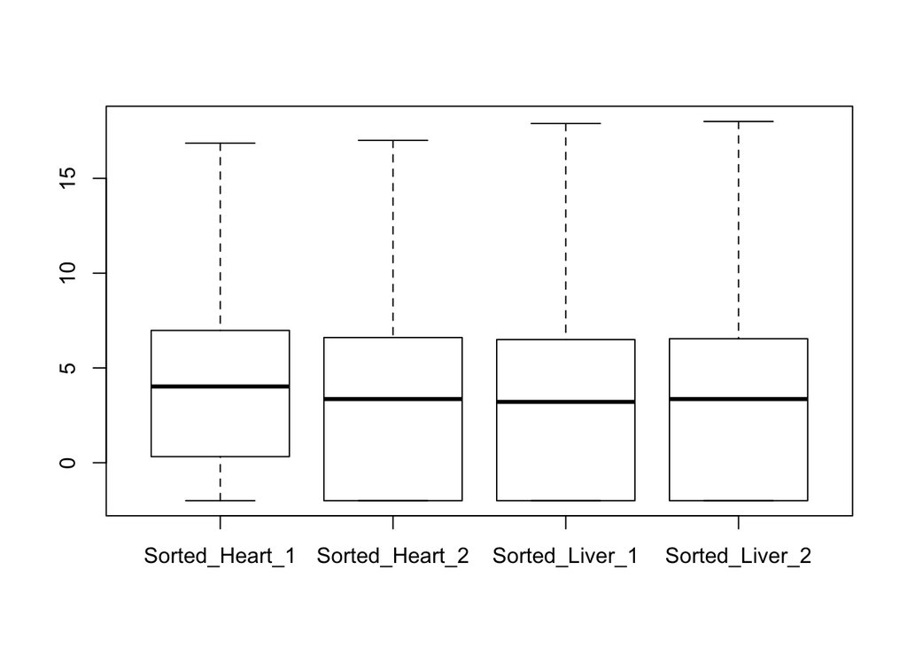

2. Run the DEseq workflow function and retrieve normalized counts, add 0.25 to normalised counts and plot a boxplot of the log2 of these updated counts.

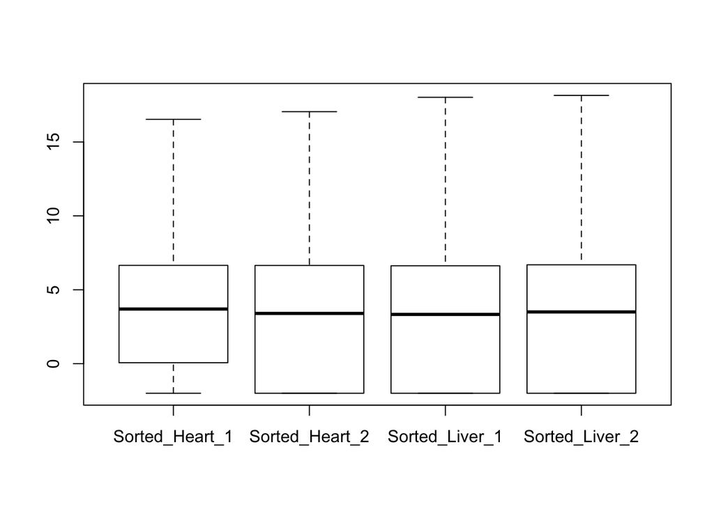

3. Plot the dispersion fit and estimates for our DEseq2 object.

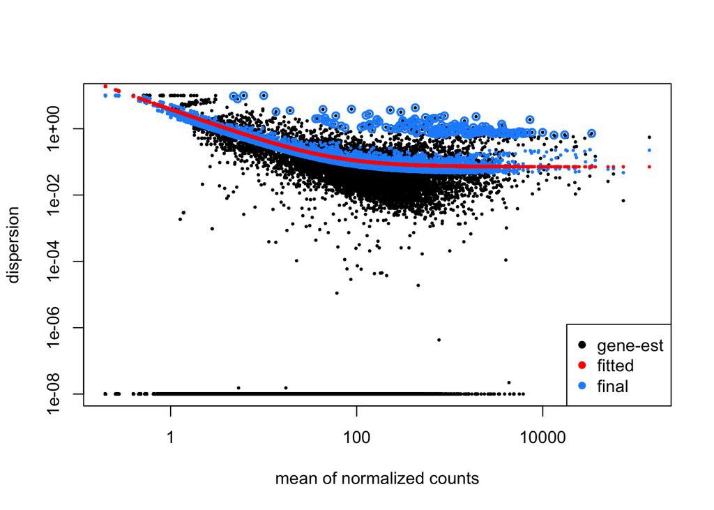

4. Add a new padj value for all genes. Make a barplot of the number of significantly (padj < 0.05) up and down regulated genes by the original padj values and our new padj values..

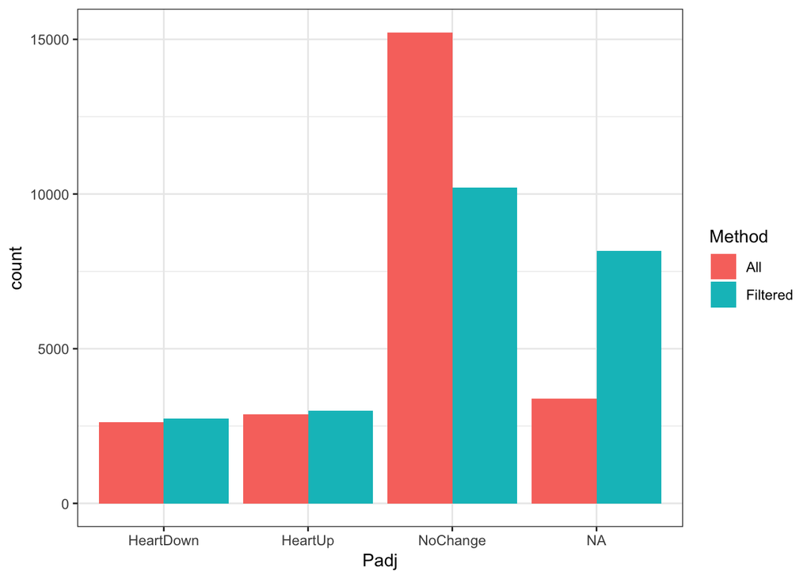

5. Produce an MA-plot before and after logFC shrinkage.

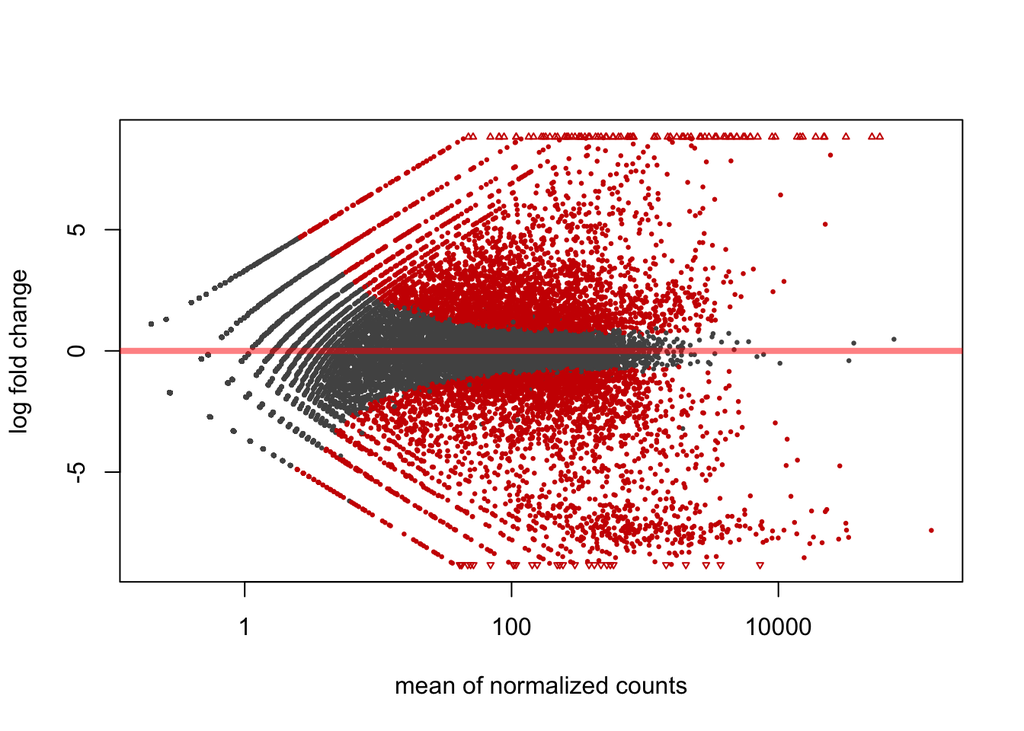

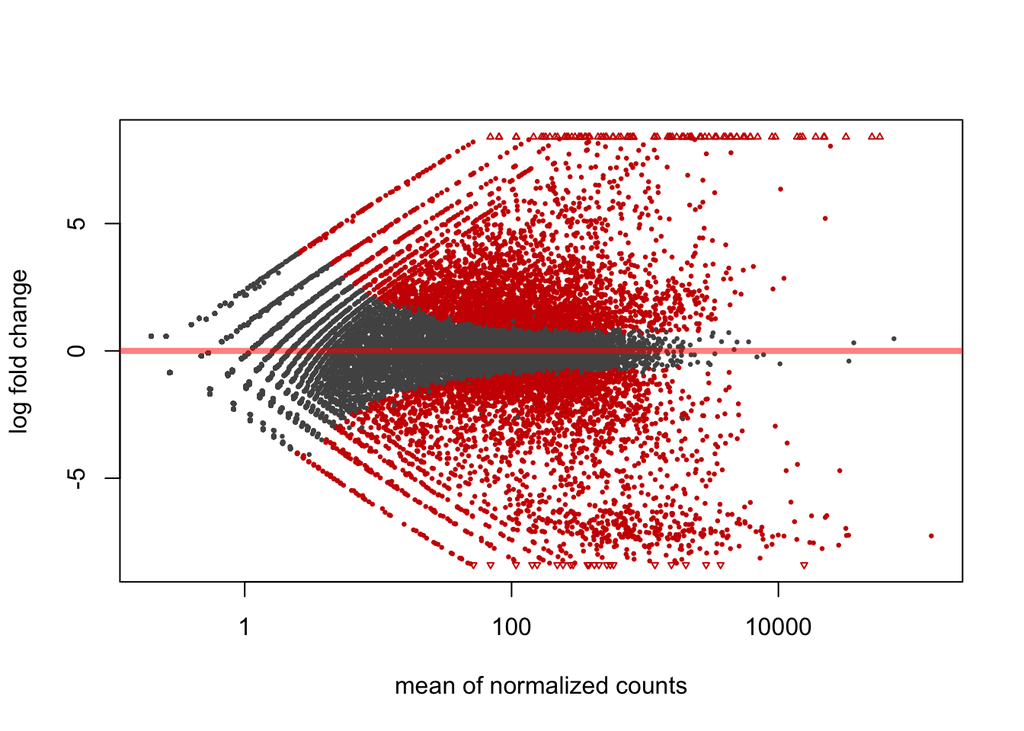

5. Identify KEGG functions enriched in genes significantly upregulated in Liver.

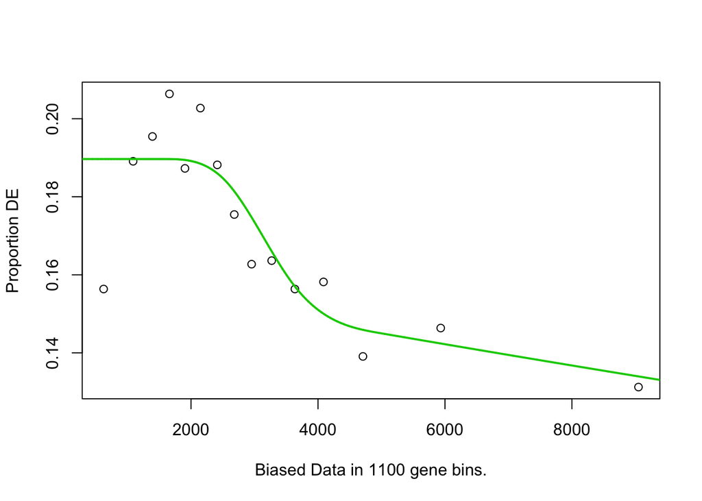

6. Plot the -log10 pvalue for top 5 terms as point plot.

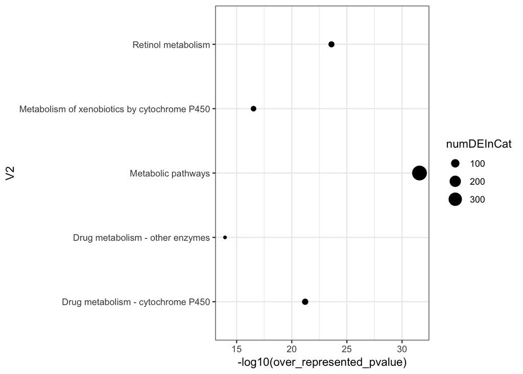

7. Using the Salmon qunatifications, plot the top 10 enriched terms in GO biological processes for genes upregulated in Heart.

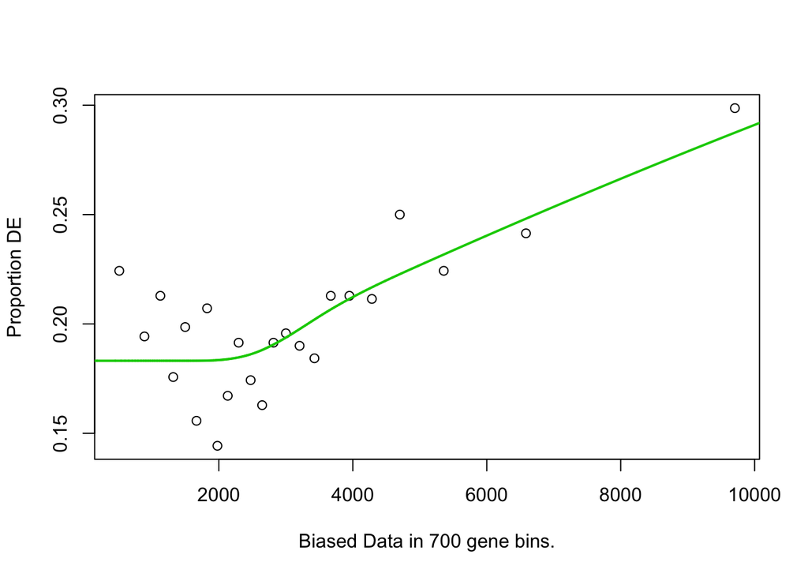

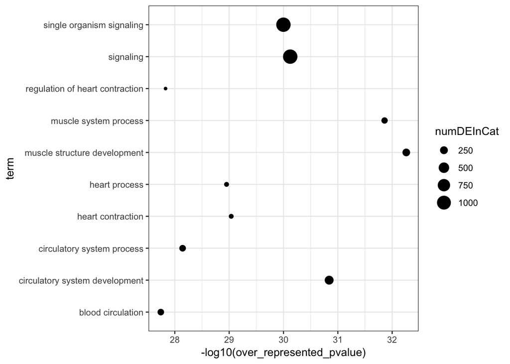